# diseases-and-ages-present-in-each-comparison-cohort-2024.01.16 14.33.16

hbeale

January 17, 2024

Version 2023.11.21_11.24.15 - focuses on genes found only relative to TCGA, not relative to any other cohort. Previous versions focused on outliers detected relative to TCGA and not treehouse, irrespective of whatever other cohorts they were outliers in

Version 2023.11.29_09.19.33 - focuses on all druggable genes, not only genes that were outliers vs one cohort or another

Version 2024.01.12_09.24.05 - removes redcap; only public data was used to generate cohorts (evidence: there are 2814 samples listed as ped aya in the public data and 2814 in the pedaya cohort used for the tertiary cohorts. there are 3211 v11 samples listed as pedaya in redcap).

Version 2024.01.16_14.33.16 - calculates % of Stanford cohort in the pediatric cohort

# LOAD v11 METADATA

```r
kbl_me <- function(x) {
    adorn_pct_formatting(x) %>%
    kbl(format.args = list(big.mark = ","), digits = c(NA, 0, NA)) %>%
    kable_styling(full_width = F)
}
```

# load public compendium data

```r
v11_metadata <- read_tsv("../input_data/clinical_TumorCompendium_v11_PolyA_2020-04-09.tsv.gz")
v11_metadata_min <- v11_metadata %>%
  select(Sample_ID = th_sampleid, age_at_dx, pedaya, disease)
```

## There is one sample with age < 30 that is not indicated as pedaya, but ignore it since we didn’t use it in the cohorts

```r
tabyl(v11_metadata$pedaya) %>% kbl_me
```

v11_metadata$pedaya

n

percent

valid_percent

No

9,426

73.9%

76.5%

Unknown

82

0.6%

0.7%

Yes, age < 30 years

2,814

22.1%

22.8%

NA

425

3.3%

```r
v11_metadata %>%
  filter(is.na(pedaya),
         ! is.na(age_at_dx)) %>%
  nrow
```

```
## [1] 1
```

```r
v11_metadata_min_updated <- v11_metadata %>%
  select(th_sampleid, age_at_dx, pedaya)%>%
  mutate(pedaya = ifelse(is.na(pedaya) & age_at_dx <30,
                          "Yes, age < 30 years",
                         pedaya))

tabyl(v11_metadata_min_updated$pedaya)  %>% kbl_me
```

v11_metadata_min_updated$pedaya

n

percent

valid_percent

No

9,426

73.9%

76.5%

Unknown

82

0.6%

0.7%

Yes, age < 30 years

2,815

22.1%

22.8%

NA

424

3.3%

# Load cohorts

```r
stanford_samples  <- read_tsv("../gather_input_data/comparison_to_non_CARE_cohorts/data/TH03_TH34_rollup.sample_list.txt",
                              col_names = "Sample_ID") %>%
  mutate(cohort = "TH03_TH34")
TCGA_samples  <- read_tsv("../gather_input_data/comparison_to_non_CARE_cohorts/data/TCGA_rollup.sample_list.txt",
                              col_names = "Sample_ID") %>%
  mutate(cohort = "TCGA")
PEDAYA_samples  <- read_tsv("../gather_input_data/comparison_to_non_CARE_cohorts/data/PEDAYA_rollup.sample_list.txt",
                              col_names = "Sample_ID") %>%
  mutate(cohort = "PEDAYA")
```

# Gather cohorts

```r
pan_cancer_samples <- v11_metadata_min %>%
  select(Sample_ID) %>%
  mutate(cohort = "Treehouse_pc")

cohorts_in_order <- c("Treehouse_pc", "TCGA", "PEDAYA", "TH03_TH34")

samples_in_cohorts <- bind_rows(
  stanford_samples,
  TCGA_samples,
  PEDAYA_samples,
  pan_cancer_samples) %>%
  left_join(v11_metadata_min) %>%
  mutate(cohort = factor(cohort, levels = cohorts_in_order))
tabyl(samples_in_cohorts,
      cohort)
```

```
##        cohort     n    percent
##  Treehouse_pc 12747 0.50033363
##          TCGA  9806 0.38489618
##        PEDAYA  2814 0.11045257
##     TH03_TH34   110 0.00431762
```

# Look at overlaps in cohorts

```r
cohort_membership <- samples_in_cohorts %>%
  mutate(value = TRUE) %>%
  pivot_wider(names_from = "cohort",
              values_fill = FALSE)

nrow(cohort_membership)
```

```
## [1] 12747
```

```r
#  the Treehouse compendium is 77% TCGA

tabyl(cohort_membership, TCGA)
```

```
##   TCGA    n  percent
##  FALSE 2941 0.230721
##   TRUE 9806 0.769279
```

```r
# the Treehouse compendium is and 22% pediatric

tabyl(cohort_membership, PEDAYA)
```

```
##  PEDAYA    n   percent
##   FALSE 9933 0.7792422
##    TRUE 2814 0.2207578
```

```r
cohort_membership %>%
  mutate(PEDAYA_and_TCGA = TCGA & PEDAYA) %>%
  tabyl(PEDAYA_and_TCGA)
```

```
##  PEDAYA_and_TCGA     n    percent
##            FALSE 12381 0.97128736
##             TRUE   366 0.02871264
```

# fix “the pediatric cohort, which includes the Stanford cohort”

i say “However, the pediatric cohort, which includes the Stanford cohort,”; check that the stanford cohort are all pediatric

```r
cohort_membership %>%
  filter(TH03_TH34,
         ! PEDAYA)
```

```
## # A tibble: 3 × 8
##   Sample_ID     age_at_dx pedaya disease     TH03_TH34 TCGA  PEDAYA Treehouse_pc
##   <chr>             <dbl> <chr>  <chr>       <lgl>     <lgl> <lgl>  <lgl>
## 1 TH03_0157_S01        60 No     Ewing sarc… TRUE      FALSE FALSE  TRUE
## 2 TH03_0160_S01        31 No     osteosarco… TRUE      FALSE FALSE  TRUE
## 3 TH34_1455_S01         3 <NA>   ependymoma  TRUE      FALSE FALSE  TRUE
```

```r
# change it to, which includes x% of the stanford cohort
cohort_membership %>%
  filter(TH03_TH34) %>%
  tabyl(PEDAYA)
```

```
##  PEDAYA   n    percent
##   FALSE   3 0.02727273
##    TRUE 107 0.97272727
```

So I can say “However, the pediatric cohort, which includes 97.3% of the Stanford cohort”

But now I realize the argument I am making is about the datasets in the study

```r
study_datasets <- read_tsv("../input_data/ckcc2_samples_and_metadata_from_redcap_2023.10.24_13.26.34.tsv")
cohort_and_study_membership <- left_join(study_datasets %>%
            select(THid) %>%
            mutate(in_study = TRUE),
          cohort_membership,
          by=c("THid" = "Sample_ID")) %>%
  replace_na(list(TH03_TH34 = FALSE,
                  TCGA = FALSE,
                  PEDAYA = FALSE,
                  Treehouse_pc = FALSE))


cohort_and_study_membership %>%
  filter(in_study,
         ! PEDAYA)
```

```
## # A tibble: 6 × 9
##   THid     in_study age_at_dx pedaya disease TH03_TH34 TCGA  PEDAYA Treehouse_pc
##   <chr>    <lgl>        <dbl> <chr>  <chr>   <lgl>     <lgl> <lgl>  <lgl>
## 1 TH34_14… TRUE            NA <NA>   <NA>    FALSE     FALSE FALSE  FALSE
## 2 TH34_14… TRUE            NA <NA>   <NA>    FALSE     FALSE FALSE  FALSE
## 3 TH34_14… TRUE             3 <NA>   ependy… TRUE      FALSE FALSE  TRUE
## 4 TH34_14… TRUE            NA <NA>   <NA>    FALSE     FALSE FALSE  FALSE
## 5 TH34_22… TRUE            NA <NA>   <NA>    FALSE     FALSE FALSE  FALSE
## 6 TH34_26… TRUE            NA <NA>   <NA>    FALSE     FALSE FALSE  FALSE
```

```r
cohort_and_study_membership %>%
  filter(in_study) %>%
  tabyl(PEDAYA)
```

```
##  PEDAYA  n   percent
##   FALSE  6 0.1714286
##    TRUE 29 0.8285714
```

So I can say “However, the pediatric cohort, which includes 82.9% of the study cohort

### (non-tcga) cohorts, which contain a minimum of X% pediatric datasets.

```r
cohort_membership %>%
  filter(TH03_TH34) %>%
  tabyl(PEDAYA)
```

```
##  PEDAYA   n    percent
##   FALSE   3 0.02727273
##    TRUE 107 0.97272727
```

```r
cohort_membership %>%
  filter(Treehouse_pc) %>%
  tabyl(PEDAYA)
```

```
##  PEDAYA    n   percent
##   FALSE 9933 0.7792422
##    TRUE 2814 0.2207578
```

# diseases in cohorts

```r
samples_in_cohorts %>%
  group_by(cohort) %>%
  mutate(cohort_total = n()) %>%
  ungroup %>%
  group_by(disease, cohort) %>%
  summarize(n = n(),
            pct_of_cohort = round(100*n/cohort_total, 2),
            stat_char = paste0(n, " (", pct_of_cohort, "%)")) %>%
  ungroup %>%
  arrange(desc(n)) %>%
  mutate(disease = factor(disease, levels = unique(disease))) %>%
  select(disease, cohort, stat_char)  %>%
  distinct() %>%
    # dplyr::group_by(disease, cohort) %>%
    # dplyr::summarise(n = dplyr::n(), .groups = "drop") %>%
    # dplyr::filter(n > 1L)
  pivot_wider(names_from = cohort, values_from = stat_char, values_fill = "0")
```

```
## # A tibble: 113 × 5
##    disease                             Treehouse_pc TCGA        PEDAYA TH03_TH34
##    <fct>                               <chr>        <chr>       <chr>  <chr>
##  1 breast invasive carcinoma           1099 (8.62%) 1099 (11.2… 10 (0… 0
##  2 acute lymphoblastic leukemia        878 (6.89%)  0           548 (… 5 (4.55%)
##  3 glioma                              738 (5.79%)  523 (5.33%) 298 (… 3 (2.73%)
##  4 acute myeloid leukemia              538 (4.22%)  173 (1.76%) 307 (… 3 (2.73%)
##  5 kidney clear cell carcinoma         532 (4.17%)  531 (5.42%) 3 (0.… 0
##  6 head & neck squamous cell carcinoma 520 (4.08%)  520 (5.3%)  7 (0.… 0
##  7 lung adenocarcinoma                 516 (4.05%)  515 (5.25%) 1 (0.… 0
##  8 thyroid carcinoma                   516 (4.05%)  512 (5.22%) 71 (2… 0
##  9 lung squamous cell carcinoma        498 (3.91%)  498 (5.08%) 0      0
## 10 prostate adenocarcinoma             496 (3.89%)  496 (5.06%) 0      0
## # ℹ 103 more rows
```

```r
samples_in_cohorts %>%
  tabyl(disease, cohort) %>%
  arrange(desc(PEDAYA)) %>%
  adorn_title() %>%
  kbl() %>%
  kable_styling(full_width = F)
```

|  | cohort |  |  |  |
| --- | --- | --- | --- | --- |
| disease | Treehouse_pc | TCGA | PEDAYA | TH03_TH34 |
| acute lymphoblastic leukemia | 878 | 0 | 548 | 5 |
| acute myeloid leukemia | 538 | 173 | 307 | 3 |
| glioma | 738 | 523 | 298 | 3 |
| neuroblastoma | 201 | 0 | 201 | 5 |
| osteosarcoma | 189 | 0 | 184 | 22 |
| wilms tumor | 137 | 0 | 136 | 3 |
| medulloblastoma | 125 | 0 | 118 | 1 |
| ependymoma | 102 | 0 | 101 | 4 |
| acute megakaryoblastic leukemia | 93 | 0 | 93 | 0 |
| Ewing sarcoma | 85 | 0 | 81 | 7 |
| thyroid carcinoma | 516 | 512 | 71 | 0 |
| testicular germ cell tumor | 155 | 154 | 62 | 0 |
| embryonal rhabdomyosarcoma | 61 | 0 | 60 | 4 |
| rhabdomyosarcoma | 57 | 0 | 54 | 2 |
| alveolar rhabdomyosarcoma | 49 | 0 | 49 | 1 |
| glioblastoma multiforme | 200 | 166 | 38 | 0 |
| adrenocortical carcinoma | 96 | 77 | 33 | 1 |
| choroid plexus carcinoma | 26 | 0 | 26 | 0 |
| pheochromocytoma & paraganglioma | 184 | 182 | 24 | 0 |
| cervical & endocervical cancer | 306 | 306 | 22 | 0 |
| lymphoma | 50 | 0 | 22 | 1 |
| skin cutaneous melanoma | 469 | 469 | 21 | 0 |
| supratentorial embryonal tumor NOS | 19 | 0 | 19 | 0 |
| hepatoblastoma | 19 | 0 | 17 | 9 |
| hepatocellular carcinoma | 375 | 368 | 17 | 1 |
| dysembryoplastic neuroepithelial tumor | 14 | 0 | 13 | 0 |
| synovial sarcoma | 41 | 10 | 13 | 3 |
| undifferentiated sarcoma NOS | 13 | 0 | 12 | 5 |
| breast invasive carcinoma | 1099 | 1099 | 10 | 0 |

[output cut: 84 more lines]

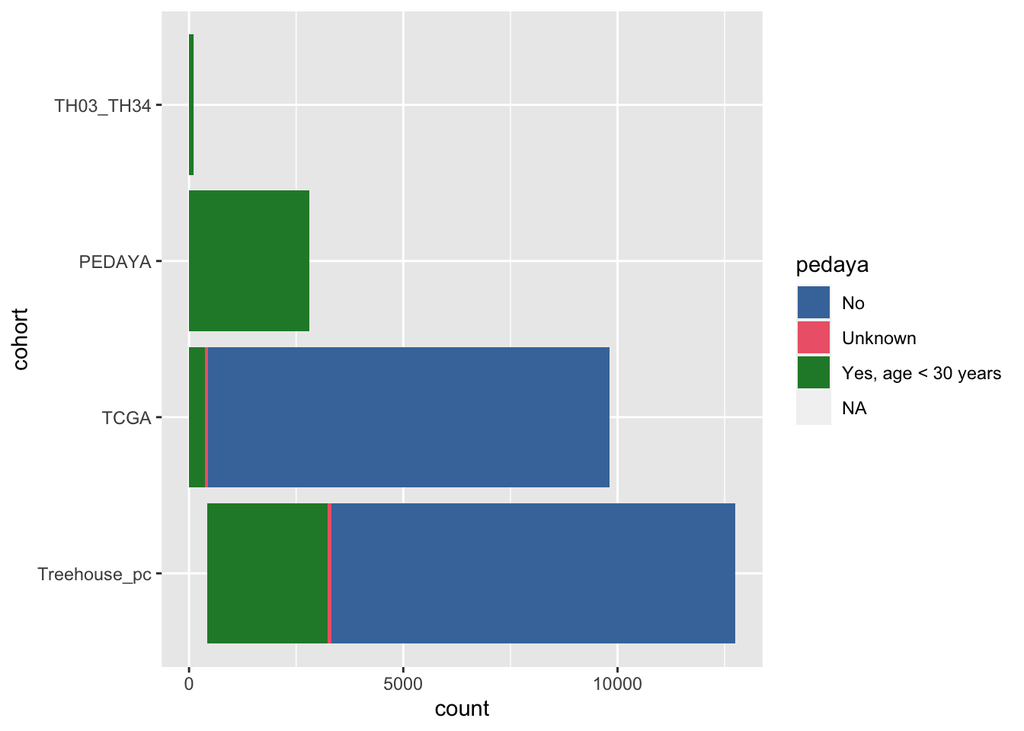

```r
ggplot(samples_in_cohorts) +
  geom_bar(aes(y=cohort, fill = pedaya)) +
  scale_fill_bright()
```

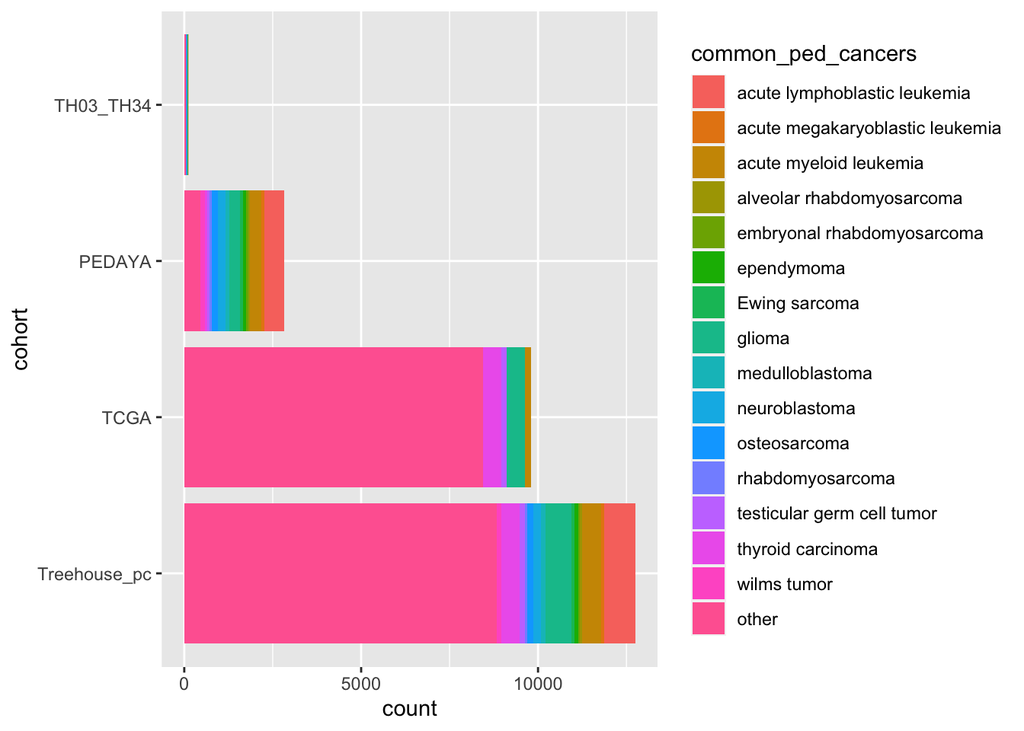

```r
most_common_ped_diseases <- samples_in_cohorts %>%
  filter(cohort == "PEDAYA") %>%
  tabyl(disease) %>%
  arrange(desc(n)) %>%
  slice_head(n=15)

disease_plot <- samples_in_cohorts %>%
  mutate(common_ped_cancers = ifelse(disease %in% most_common_ped_diseases$disease,
                                     disease,
                                     "other") %>%
           factor() %>%
           fct_relevel("other", after=Inf))


ggplot(disease_plot) +
  geom_bar(aes(y=cohort, fill = common_ped_cancers))
```